# daily-happiness-employee-turnover

LC

09 janvier 2020

# Daily Happiness & Employee Turnover

## Presentation

A dataset found on https://www.kaggle.com/harriken/employeeturnover.

This dataset is from the spanish company **myhappyforce**, an employee survey company. They send everyday the question *How happy ar you today at work?* to the employees, they then can answer with a vote from 1 to 4 and leave a comment.

For this case we will use two datasets:

- *churn* which stores each employee and if this employee churned (if he left or has been fired)
- *votes* which stores every votes, who voted and the date this employee voted.

```r
str(churn)
```

```
## 'data.frame':    4847 obs. of  5 variables:
##  $ employee             : int  512 -2 2 487 3 -4 4 516 475 5 ...
##  $ companyAlias         : Factor w/ 37 levels "5370af43e4b0cff95558c12a",..: 12 12 12 12 12 12 12 12 12 12 ...
##  $ numVotes             : int  4 0 72 14 22 0 195 29 15 42 ...
##  $ lastParticipationDate: Factor w/ 1844 levels "Fri Apr 01 02:00:00 CEST 2016",..: 1030 1656 191 854 1009 694 570 609 944 1408 ...
##  $ stillExists          : Factor w/ 2 levels "false","true": 2 1 2 1 2 1 2 2 1 2 ...
```

```r
str(votes)
```

```
## 'data.frame':    221232 obs. of  4 variables:
##  $ employee    : int  31 33 79 94 16 20 22 41 83 12 ...
##  $ companyAlias: Factor w/ 37 levels "5370af43e4b0cff95558c12a",..: 12 12 12 12 12 12 12 12 12 12 ...
##  $ voteDate    : Factor w/ 797 levels "Fri Apr 01 02:00:00 CEST 2016",..: 145 145 145 145 145 145 145 145 145 145 ...
##  $ vote        : int  4 4 4 4 2 2 2 2 2 3 ...
```

> The main goal of this work will be to show a correlation between the happiness rate in a company and its turnover.

## Clean

```r
#ignore negative employees ids
churn <- churn %>% filter(employee > 0)

#delete companies with less than 30 votes
votes <- votes %>% filter(!(companyAlias %in% (churn %>%
                                                 group_by(companyAlias) %>%
                                                 summarise(votes = sum(numVotes)) %>%
                                                 filter(votes < 30))$companyAlias))
churn <- churn %>% filter(!(companyAlias %in% (churn %>%
                                                 group_by(companyAlias) %>%
                                                 summarise(votes = sum(numVotes)) %>%
                                                 filter(votes < 30))$companyAlias))
churn <- droplevels(churn)
votes <- droplevels(votes)

#nicer Alias
if (all(levels(churn$companyAlias) == levels(votes$companyAlias)) == TRUE) { #check if alias are the same
  levels(churn$companyAlias) <- paste("X", 1:length(levels(churn$companyAlias)), sep = "")
  levels(votes$companyAlias) <- paste("X", 1:length(levels(votes$companyAlias)), sep = "")
} else {
  print("error: alias are different")
}

#new employees ids
churn$employee <- paste(churn$employee, churn$companyAlias, sep = "")
votes$employee <- paste(votes$employee, votes$companyAlias, sep = "")

#date standardization
votes$wday <- factor(str_sub(votes$voteDate, 1, 3),
                levels = c("Mon", "Tue", "Wed", "Thu", "Fri", "Sat", "Sun"))
votes$month <- factor(str_sub(votes$voteDate, 5, 7),
                levels = c("Jan", "Feb", "Mar", "Apr", "May", "Jun", "Jul", "Aug", "Sep", "Oct", "Nov", "Dec"))
votes$voteDate <- ymd(paste(str_sub(votes$voteDate, -4, -1), str_sub(votes$voteDate, 5, 10)))
votes$day <- day(votes$voteDate)
votes$voteYear <- year(votes$voteDate)
votes$nwday <- wday(votes$voteDate, week_start = getOption("lubridate.week.start", 1)) - 1 #0 = Mon, 6 = Sun
votes$yday <- yday(votes$voteDate) #12th february = 43
votes$week <- isoweek(votes$voteDate)
votes[votes$week %in% c(52,53) & votes$month == "Jan", ]$week <- 0
votes$week <- factor(votes$week, levels = c(0:53))
churn$lastParticipationDate <- ymd(paste(str_sub(churn$lastParticipationDate, -4, -1),
                                         str_sub(churn$lastParticipationDate, 5, 10)))

#delete duplicates
churn <- churn %>% filter(!(employee %in% (churn %>% group_by(employee) %>%
                                             summarise(count = n()) %>%
                                             filter(count > 1))$employee))
votes$temp <- paste(votes$employee, votes$voteDate, sep = "") #temporary id employee & voteDate
votes <- votes %>% filter(!(temp %in% (votes %>% group_by(temp) %>%
                                         summarise(count = n()) %>%
                                         filter(count > 1))$temp))
votes$temp <- NULL
```

## Daily Happiness

### Let’s compute happiness rate by companies

```r
happinessRate <- votes %>%
  group_by(companyAlias) %>%
  summarise(happinessRate = round(mean(vote), 2))
```

### Graphs about happiness rate

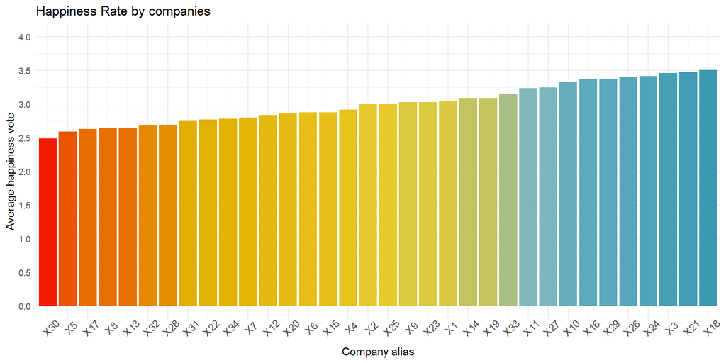

Just an overview of the companies to show how a the average vote can differ from a company to another one.

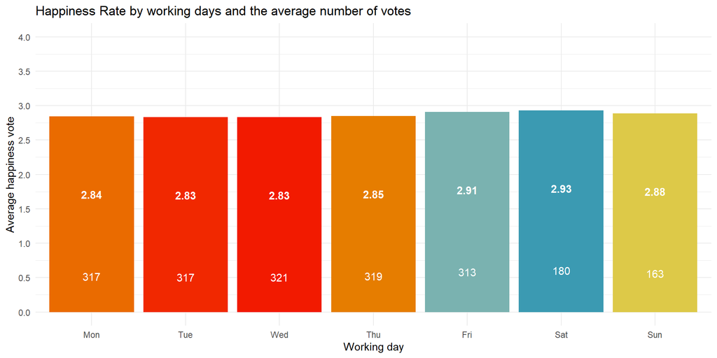

The “weekend effect” appears here, grades from friday to sunday are higher.  
Note however that the average number of votes on the weekend is lower than the rest of the week (*163* and *180* compared to *317* during workweek).

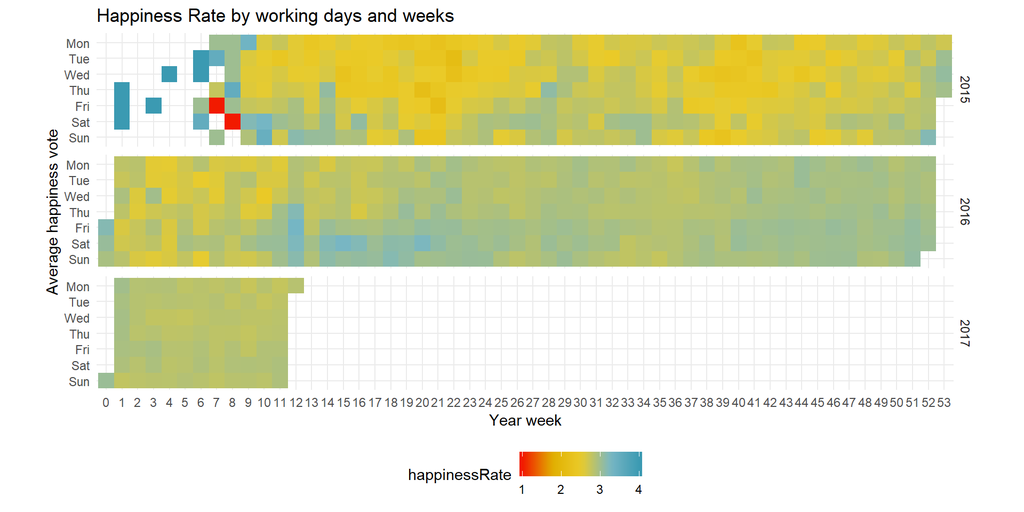

The happiness rate can also vary due to the season. As the graph above shows, the happiness rate vary during the year.

## Employee Turnover

### Correlation between turnover and happiness rate

$turnover \ rate = 1 - \frac{Employees}{Employees \ + \ Churned}$  
According to LinkedIn, an average annual worldwide employee turnover rate is 10.9%.

```r
companies <- merge(votes %>% group_by(companyAlias) %>% summarise(vote = mean(vote),
                                                                  wday = mean(nwday),
                                                                  yday = mean(yday),
                                                                  year = mean(voteYear)),
                   churn %>% group_by(companyAlias) %>%
                     summarise(true = sum(stillExists == "true"), total = n()) %>%
                     mutate(turnoverRate = round((1 - true / total), 5)),
                   by = c("companyAlias"))[-c(6:7)]
rownames(companies) <- companies$companyAlias
companies <- companies[-1]
round(cor(companies, method = c("pearson")), 3)
```

```
##                vote   wday   yday   year turnoverRate
## vote          1.000 -0.008  0.301 -0.256       -0.147
## wday         -0.008  1.000  0.224 -0.219        0.115
## yday          0.301  0.224  1.000 -0.596        0.084
## year         -0.256 -0.219 -0.596  1.000       -0.095
## turnoverRate -0.147  0.115  0.084 -0.095        1.000
```

We can spot a negative correlation between the vote and the turnover rate.

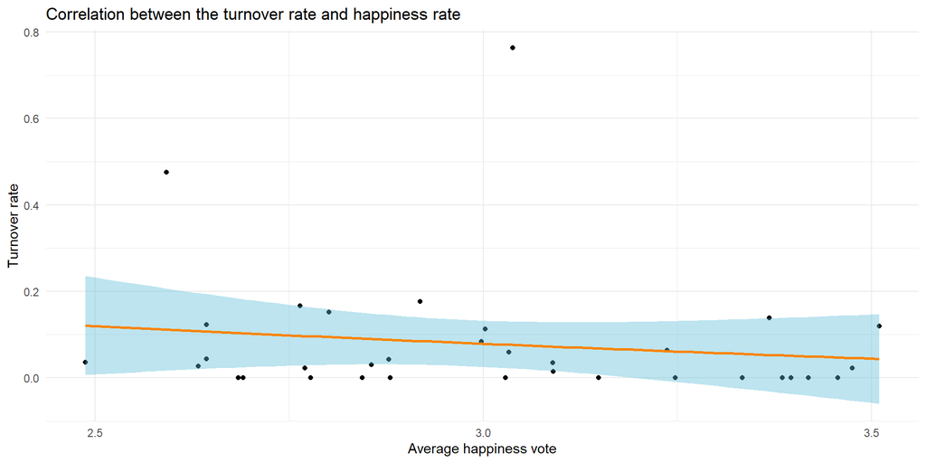

## Raw code

```r
##Presentation

list.of.packages <- c("tidyverse", "stringr", "lubridate", "ggplot2", "ggthemes", "wesanderson")
new.packages <- list.of.packages[!(list.of.packages %in% installed.packages()[,"Package"])]
if(length(new.packages)) install.packages(new.packages)
library(tidyverse)
library(stringr)
library(lubridate)
library(ggplot2)
library(ggthemes)
library(wesanderson)

churn <- read.csv(file = "./data/churn.csv")
votes <- read.csv(file = "./data/votes.csv")

str(churn)
str(votes)

##Clean

#ignore negative employees ids
churn <- churn %>% filter(employee > 0)

#delete companies with less than 30 votes
votes <- votes %>% filter(!(companyAlias %in% (churn %>%
                                                 group_by(companyAlias) %>%
                                                 summarise(votes = sum(numVotes)) %>%
                                                 filter(votes < 30))$companyAlias))
churn <- churn %>% filter(!(companyAlias %in% (churn %>%
                                                 group_by(companyAlias) %>%
                                                 summarise(votes = sum(numVotes)) %>%
                                                 filter(votes < 30))$companyAlias))
churn <- droplevels(churn)
votes <- droplevels(votes)

#nicer Alias
if (all(levels(churn$companyAlias) == levels(votes$companyAlias)) == TRUE) { #check if alias are the same
  levels(churn$companyAlias) <- paste("X", 1:length(levels(churn$companyAlias)), sep = "")
  levels(votes$companyAlias) <- paste("X", 1:length(levels(votes$companyAlias)), sep = "")
} else {
  print("error: alias are different")
}

#new employees ids
churn$employee <- paste(churn$employee, churn$companyAlias, sep = "")
votes$employee <- paste(votes$employee, votes$companyAlias, sep = "")

#date standardization
votes$wday <- factor(str_sub(votes$voteDate, 1, 3),
                levels = c("Mon", "Tue", "Wed", "Thu", "Fri", "Sat", "Sun"))
votes$month <- factor(str_sub(votes$voteDate, 5, 7),
                levels = c("Jan", "Feb", "Mar", "Apr", "May", "Jun", "Jul", "Aug", "Sep", "Oct", "Nov", "Dec"))
votes$voteDate <- ymd(paste(str_sub(votes$voteDate, -4, -1), str_sub(votes$voteDate, 5, 10)))
votes$day <- day(votes$voteDate)
votes$voteYear <- year(votes$voteDate)
votes$nwday <- wday(votes$voteDate, week_start = getOption("lubridate.week.start", 1)) - 1 #0 = Mon, 6 = Sun
votes$yday <- yday(votes$voteDate) #12th february = 43
votes$week <- isoweek(votes$voteDate)
votes[votes$week %in% c(52,53) & votes$month == "Jan", ]$week <- 0
votes$week <- factor(votes$week, levels = c(0:53))
churn$lastParticipationDate <- ymd(paste(str_sub(churn$lastParticipationDate, -4, -1),
                                         str_sub(churn$lastParticipationDate, 5, 10)))

#delete duplicates
churn <- churn %>% filter(!(employee %in% (churn %>% group_by(employee) %>%
                                             summarise(count = n()) %>%
                                             filter(count > 1))$employee))
votes$temp <- paste(votes$employee, votes$voteDate, sep = "") #temporary id employee & voteDate
votes <- votes %>% filter(!(temp %in% (votes %>% group_by(temp) %>%
                                         summarise(count = n()) %>%
                                         filter(count > 1))$temp))
votes$temp <- NULL

##Daily Happiness

happinessRate <- votes %>%
  group_by(companyAlias) %>%
  summarise(happinessRate = round(mean(vote), 2))

#Happiness Rate by Company
ggplot(happinessRate, aes(reorder(companyAlias, happinessRate), happinessRate, fill = happinessRate)) +
  geom_bar(stat = "identity") +
  scale_fill_gradientn(colors = rev(wes_palette("Zissou1", 34, type = "continuous"))) +
  theme_minimal() +
  theme(legend.position = "none",
        axis.text.x = element_text(angle = 45, size = 10),
        axis.text.y = element_text(vjust = 0.5)) +
  scale_y_continuous(breaks = seq(0,5,0.5), limits = c(0, 4)) +
  labs(title = "Happiness Rate by companies", x = "Company alias", y = "Average happiness vote")

#hapinessRate Mean by wday
ggplot(votes %>% group_by(wday) %>% summarise(happinessRate = mean(vote), count = n()/n_distinct(voteDate)),
       aes(x = wday, y = happinessRate, fill = happinessRate)) +
  geom_bar(stat = "identity") +
  scale_fill_gradientn(colors = rev(wes_palette("Zissou1", 7, type = "continuous"))) +
  theme_minimal() +
  theme(legend.position = "none") +
  scale_y_continuous(breaks = seq(0,5,0.5), limits = c(0, 4)) +
  geom_text(aes(label = round(happinessRate, 2)), vjust = 10, color = "white", fontface = 2) +
  geom_text(aes(label = round(count, 0)), vjust = 20, color = "white") +
  labs(title = "Happiness Rate by working days and the average number of votes", x = "Working day", y = "Average happiness vote")

#heatmap
ggplot(data = votes %>% filter(voteYear > 2014) %>% group_by(day, wday, month, week, voteYear) %>%
         summarise(happinessRate = mean(vote)), aes(x = week, y = fct_rev(wday))) +
  geom_tile(aes(fill = happinessRate)) +
  scale_fill_gradientn(colors = rev(wes_palette("Zissou1", 50, type = "continuous"))) +
  theme_minimal() +
  theme(legend.position = "bottom") +
  facet_grid(voteYear~.) +
  coord_fixed() +
  labs(title = "Happiness Rate by working days and weeks", x = "Year week", y = "Average happiness vote")

##Employee Turnover

companies <- merge(votes %>% group_by(companyAlias) %>% summarise(vote = mean(vote),
                                                                  wday = mean(nwday),
                                                                  yday = mean(yday),
                                                                  year = mean(voteYear)),
                   churn %>% group_by(companyAlias) %>%
                     summarise(true = sum(stillExists == "true"), total = n()) %>%
                     mutate(turnoverRate = round((1 - true / total), 5)),
                   by = c("companyAlias"))[-c(6:7)]
rownames(companies) <- companies$companyAlias
companies <- companies[-1]
round(cor(companies, method = c("pearson")), 3)

ggplot(companies, aes(x = vote, y = turnoverRate)) +
  geom_point() +
  geom_smooth(method = lm, formula = y ~ log(x), colour = wes_palette("Darjeeling1")[4], fill = wes_palette("Darjeeling1")[5]) +
  theme_minimal() +
  scale_x_continuous(breaks = seq(2, 4, 0.5)) +
  labs(title = "Correlation between the turnover rate and happiness rate", x = "Average happiness vote", y = "Turnover rate")
```